# MULTISPECTOR — RF-DETR Segmentation Large / Dataset V2

This notebook intentionally stops before training if class order, label integrity, split leakage, or RF-DETR Large's 200-query capacity is unsafe.

## 1. Server paths, imports, and output folders

```python
from pathlib import Path
import gc
import hashlib
import importlib.metadata as metadata
import json
import os
import platform
import random
import shutil
import sys
import time

PROJECT_ROOT = Path.cwd().resolve()
if PROJECT_ROOT.name == "notebooks":
    PROJECT_ROOT = PROJECT_ROOT.parent

PREFERRED_DATASET_DIR = Path("/home/multispector2/wheatv2/dataset_v2")
RUN_ROOT = Path("/home/multispector2/testdino/outputRFDetrV2")
SMOKE_DIR = RUN_ROOT / "smoke"
TRAIN_DIR = RUN_ROOT / "training"
REPORT_DIR = RUN_ROOT / "reports"

SRC_DIR = PROJECT_ROOT / "src"
if str(SRC_DIR) not in sys.path:
    sys.path.insert(0, str(SRC_DIR))

# Must be set before importing torch; reduces CUDA allocator fragmentation on long runs.
os.environ.setdefault("PYTORCH_CUDA_ALLOC_CONF", "expandable_segments:True")

import cv2
import matplotlib.pyplot as plt
import numpy as np
import pandas as pd
from PIL import Image
import seaborn as sns
import torch
import yaml
from IPython.display import Markdown, display

from multispector_rfdetr import audit_dataset, plot_class_balance, plot_yolo_samples


def locate_dataset_root(preferred: Path) -> Path:
    preferred = preferred.expanduser().resolve()
    assert preferred.is_dir(), f"Dataset directory not found: {preferred}"
    direct = [preferred / "data.yaml", preferred / "data.yml"]
    if any(path.is_file() for path in direct):
        return preferred
    nested = sorted({path.parent for path in preferred.glob("*/data.y*ml")})
    assert len(nested) == 1, (
        f"Expected one data.yaml below {preferred}, found {len(nested)}: {nested}"
    )
    return nested[0]


DATASET_DIR = locate_dataset_root(PREFERRED_DATASET_DIR)
for directory in (RUN_ROOT, SMOKE_DIR, TRAIN_DIR, REPORT_DIR):
    directory.mkdir(parents=True, exist_ok=True)

print(f"Project root : {PROJECT_ROOT}")
print(f"Dataset V2  : {DATASET_DIR}")
print(f"Run outputs : {RUN_ROOT}")
print(f"Training    : {TRAIN_DIR}")
```

```
Project root : /home/multispector2/testdino
Dataset V2  : /home/multispector2/wheatv2/dataset_v2
Run outputs : /home/multispector2/testdino/outputRFDetrV2
Training    : /home/multispector2/testdino/outputRFDetrV2/training
```

## 2. CUDA and environment check

```python
environment = {
    "python": platform.python_version(),
    "torch": torch.__version__,
    "torch_cuda_build": torch.version.cuda,
    "cuda_available": torch.cuda.is_available(),
    "gpu": torch.cuda.get_device_name(0) if torch.cuda.is_available() else "CPU only",
    "rfdetr": metadata.version("rfdetr"),
}
display(pd.DataFrame(environment.items(), columns=["item", "value"]))

assert torch.cuda.is_available(), "CUDA GPU is required for RF-DETR Segmentation Large training."
properties = torch.cuda.get_device_properties(0)
print(f"GPU VRAM: {properties.total_memory / 1024**3:.1f} GB")
torch.zeros(1, device="cuda")
print("CUDA tensor test passed.")
```

|  | item | value |
| --- | --- | --- |
| 0 | python | 3.12.11 |
| 1 | torch | 2.13.0+cu126 |
| 2 | torch_cuda_build | 12.6 |
| 3 | cuda_available | True |
| 4 | gpu | NVIDIA RTX 4000 SFF Ada Generation |
| 5 | rfdetr | 1.9.3 |

```
GPU VRAM: 19.5 GB
CUDA tensor test passed.
```

## 3. Normalize and verify Dataset V2 YAML

The class order is a hard safety check. The website and all reports expect:

`0 = bad seed`, `1 = healthy seed`, `2 = impurity`.

```python
EXPECTED_CLASS_NAMES = ["bad seed", "healthy seed", "impurity"]

source_yaml = DATASET_DIR / "data.yaml"
if not source_yaml.exists():
    source_yaml = DATASET_DIR / "data.yml"
assert source_yaml.is_file(), f"Dataset YAML not found under {DATASET_DIR}"

with source_yaml.open("r", encoding="utf-8") as handle:
    dataset_config = yaml.safe_load(handle) or {}

raw_names = dataset_config.get("names", [])
if isinstance(raw_names, dict):
    yaml_class_names = [str(raw_names[key]) for key in sorted(raw_names, key=lambda value: int(value))]
else:
    yaml_class_names = [str(name) for name in raw_names]

print("Class mapping declared by Dataset V2:")
for class_id, class_name in enumerate(yaml_class_names):
    print(f"  {class_id} -> {class_name}")

assert yaml_class_names == EXPECTED_CLASS_NAMES, (
    "CLASS ORDER SAFETY STOP. Expected "
    f"{EXPECTED_CLASS_NAMES}, but data.yaml declares {yaml_class_names}. "
    "Review the V2 annotations before changing this assertion."
)

split_folders = {"train": "train", "val": "valid", "test": "test"}
for yaml_key, folder in split_folders.items():
    images_dir = DATASET_DIR / folder / "images"
    labels_dir = DATASET_DIR / folder / "labels"
    assert images_dir.is_dir(), f"Missing images directory: {images_dir}"
    assert labels_dir.is_dir(), f"Missing labels directory: {labels_dir}"
    dataset_config[yaml_key] = f"{folder}/images"

dataset_config["nc"] = len(EXPECTED_CLASS_NAMES)
dataset_config["names"] = EXPECTED_CLASS_NAMES

normalized_yaml = DATASET_DIR / "data.yaml"
backup_yaml = DATASET_DIR / f"{source_yaml.name}.before_multispector_v2"
if not backup_yaml.exists():
    shutil.copy2(source_yaml, backup_yaml)

with normalized_yaml.open("w", encoding="utf-8") as handle:
    yaml.safe_dump(dataset_config, handle, sort_keys=False, allow_unicode=True)

print(f"Normalized YAML: {normalized_yaml}")
for yaml_key, folder in split_folders.items():
    resolved = (DATASET_DIR / dataset_config[yaml_key]).resolve()
    print(f"{yaml_key:>5}: {resolved} | exists={resolved.is_dir()}")
```

```
Class mapping declared by Dataset V2:
  0 -> bad seed
  1 -> healthy seed
  2 -> impurity
Normalized YAML: /home/multispector2/wheatv2/dataset_v2/data.yaml
train: /home/multispector2/wheatv2/dataset_v2/train/images | exists=True
  val: /home/multispector2/wheatv2/dataset_v2/valid/images | exists=True
 test: /home/multispector2/wheatv2/dataset_v2/test/images | exists=True
```

## 4. Automatically rebuild source-safe splits

The original Dataset V2 is audited first. If augmented copies of one source occur in different splits, this cell creates a deterministic 80/10/10 derived dataset under `outputRFDetrV2`, grouped by the pre-`.rf.` source ID. The original images and labels are not moved or deleted. Train retains its augmentation variants; validation and test retain one representative image per independent source.

```python
from collections import defaultdict
import os

SOURCE_DATASET_DIR = DATASET_DIR
SOURCE_SPLIT_REPORT = audit_dataset(SOURCE_DATASET_DIR, deep_coordinate_check=True)
display(Markdown("### Original Dataset V2 split overlap"))
display(SOURCE_SPLIT_REPORT["source_overlaps"])

SOURCE_SPLIT_REPORT["source_overlaps"].to_csv(
    REPORT_DIR / "original_source_overlaps.csv",
    index=False,
)
SOURCE_SPLIT_REPORT["issues"].to_csv(
    REPORT_DIR / "original_dataset_issues.csv",
    index=False,
)
if not SOURCE_SPLIT_REPORT["issues"].empty:
    display(SOURCE_SPLIT_REPORT["issues"].head(100))
assert SOURCE_SPLIT_REPORT["issues"].empty, (
    f"SOURCE DATASET STOP: {len(SOURCE_SPLIT_REPORT['issues'])} structural/label issues found. "
    f"Review {REPORT_DIR / 'original_dataset_issues.csv'}."
)


def source_id_from_stem(stem: str) -> str:
    return stem.split(".rf.", maxsplit=1)[0]


def label_class_counts(label_path: Path, class_count: int) -> list[int]:
    counts = [0] * class_count
    for line in label_path.read_text(encoding="utf-8").splitlines():
        tokens = line.split()
        if tokens:
            counts[int(tokens[0])] += 1
    return counts


source_signature = hashlib.sha256()
for path in sorted(SOURCE_DATASET_DIR.rglob("*")):
    if not path.is_file() or path.name.endswith(".cache"):
        continue
    relative = path.relative_to(SOURCE_DATASET_DIR).as_posix()
    source_signature.update(relative.encode("utf-8"))
    source_signature.update(str(path.stat().st_size).encode("ascii"))
    if path.suffix.lower() in {".txt", ".yaml", ".yml"}:
        source_signature.update(path.read_bytes())
SOURCE_SIGNATURE = source_signature.hexdigest()

GROUPED_DATASET_DIR = RUN_ROOT / f"dataset_v2_grouped_{SOURCE_SIGNATURE[:12]}"
GROUPED_MARKER = GROUPED_DATASET_DIR / "grouped_split_manifest.json"
GROUP_SPLIT_SEED = 20260825
TARGET_RATIOS = {"train": 0.80, "valid": 0.10, "test": 0.10}

source_overlap_count = int(
    SOURCE_SPLIT_REPORT["source_overlaps"]["likely_shared_sources"].sum()
)

if source_overlap_count == 0:
    print("Original Dataset V2 already has source-safe splits; no rebuild is needed.")
    DATASET_DIR = SOURCE_DATASET_DIR
else:
    records_by_source: dict[str, list[dict]] = defaultdict(list)
    valid_image_suffixes = {".jpg", ".jpeg", ".png", ".bmp", ".tif", ".tiff", ".webp"}

    for original_split in ("train", "valid", "test"):
        images_dir = SOURCE_DATASET_DIR / original_split / "images"
        labels_dir = SOURCE_DATASET_DIR / original_split / "labels"
        for image_path in sorted(images_dir.iterdir()):
            if not image_path.is_file() or image_path.suffix.lower() not in valid_image_suffixes:
                continue
            label_path = labels_dir / f"{image_path.stem}.txt"
            assert label_path.is_file(), f"Missing label for {image_path}"
            source_id = source_id_from_stem(image_path.stem)
            records_by_source[source_id].append({
                "source_id": source_id,
                "original_split": original_split,
                "image_path": image_path,
                "label_path": label_path,
                "class_counts": label_class_counts(label_path, len(EXPECTED_CLASS_NAMES)),
            })

    group_rows = []
    strata: dict[tuple[bool, ...], list[str]] = defaultdict(list)
    for source_id, records in records_by_source.items():
        class_counts = np.sum(
            np.asarray([record["class_counts"] for record in records], dtype=np.int64),
            axis=0,
        )
        dominant_class = int(np.argmax(class_counts))
        class_presence = tuple(bool(value) for value in class_counts)
        is_mixed = sum(class_presence) > 1
        strata[class_presence].append(source_id)
        group_rows.append({
            "source_id": source_id,
            "original_records": len(records),
            "dominant_class_id": dominant_class,
            "dominant_class_name": EXPECTED_CLASS_NAMES[dominant_class],
            "mixed_classes": is_mixed,
            "class_presence": "/".join("1" if value else "0" for value in class_presence),
            **{
                f"instances_{class_name}": int(class_counts[class_id])
                for class_id, class_name in enumerate(EXPECTED_CLASS_NAMES)
            },
        })

    assignments: dict[str, str] = {}
    rng = random.Random(GROUP_SPLIT_SEED)
    for stratum, source_ids in sorted(strata.items()):
        source_ids = sorted(source_ids)
        rng.shuffle(source_ids)
        count = len(source_ids)
        if count >= 10:
            test_count = max(1, round(count * TARGET_RATIOS["test"]))
            valid_count = max(1, round(count * TARGET_RATIOS["valid"]))
        elif count >= 3:
            test_count = 1
            valid_count = 1
        elif count == 2:
            test_count = 0
            valid_count = 1
        else:
            test_count = 0
            valid_count = 0

        for source_id in source_ids[:test_count]:
            assignments[source_id] = "test"
        for source_id in source_ids[test_count : test_count + valid_count]:
            assignments[source_id] = "valid"
        for source_id in source_ids[test_count + valid_count :]:
            assignments[source_id] = "train"

    assignment_frame = pd.DataFrame(group_rows)
    assignment_frame["assigned_split"] = assignment_frame["source_id"].map(assignments)
    assignment_frame = assignment_frame.sort_values(["assigned_split", "source_id"])
    assignment_frame.to_csv(REPORT_DIR / "grouped_source_assignments.csv", index=False)

    if GROUPED_DATASET_DIR.exists() and not GROUPED_MARKER.exists():
        raise RuntimeError(
            f"Grouped dataset directory exists without a completion marker: {GROUPED_DATASET_DIR}. "
            "Move that incomplete derived directory aside, then rerun this cell."
        )

    if not GROUPED_MARKER.exists():
        for target_split in ("train", "valid", "test"):
            (GROUPED_DATASET_DIR / target_split / "images").mkdir(parents=True, exist_ok=True)
            (GROUPED_DATASET_DIR / target_split / "labels").mkdir(parents=True, exist_ok=True)

        def link_or_copy(source: Path, destination: Path) -> None:
            if destination.exists() or destination.is_symlink():
                return
            try:
                os.symlink(source.resolve(), destination)
            except OSError:
                shutil.copy2(source, destination)

        materialized_records = {"train": 0, "valid": 0, "test": 0}
        for source_id, records in sorted(records_by_source.items()):
            target_split = assignments[source_id]
            ordered_records = sorted(
                records,
                key=lambda record: (
                    record["original_split"] != target_split,
                    record["image_path"].name,
                ),
            )
            # Keep all augmentation variants in train. Validation and test keep
            # one representative per source so metrics are source-independent.
            selected_records = ordered_records if target_split == "train" else ordered_records[:1]
            for record_index, record in enumerate(selected_records):
                # Preserve the exact source ID before `.rf.` so the second audit can
                # independently prove that no source family crosses split boundaries.
                safe_stem = (
                    f"{source_id}.rf.grouped_{record['original_split']}_{record_index:03d}"
                )
                target_image = (
                    GROUPED_DATASET_DIR / target_split / "images" /
                    f"{safe_stem}{record['image_path'].suffix.lower()}"
                )
                target_label = GROUPED_DATASET_DIR / target_split / "labels" / f"{safe_stem}.txt"
                link_or_copy(record["image_path"], target_image)
                link_or_copy(record["label_path"], target_label)
                materialized_records[target_split] += 1

        grouped_config = {
            "train": "train/images",
            "val": "valid/images",
            "test": "test/images",
            "nc": len(EXPECTED_CLASS_NAMES),
            "names": EXPECTED_CLASS_NAMES,
        }
        with (GROUPED_DATASET_DIR / "data.yaml").open("w", encoding="utf-8") as handle:
            yaml.safe_dump(grouped_config, handle, sort_keys=False, allow_unicode=True)

        marker_payload = {
            "source_dataset": str(SOURCE_DATASET_DIR),
            "source_signature": SOURCE_SIGNATURE,
            "seed": GROUP_SPLIT_SEED,
            "target_ratios": TARGET_RATIOS,
            "source_groups": len(records_by_source),
            "assigned_source_groups": {
                str(split_name): int(group_count)
                for split_name, group_count in pd.Series(assignments).value_counts().items()
            },
            "materialized_records": materialized_records,
            "validation_test_policy": "one representative image per source",
        }
        GROUPED_MARKER.write_text(
            json.dumps(marker_payload, indent=2, sort_keys=True) + "\n",
            encoding="utf-8",
        )
        print(f"Created source-safe grouped dataset: {GROUPED_DATASET_DIR}")
    else:
        print(f"Reusing completed grouped dataset: {GROUPED_DATASET_DIR}")

    DATASET_DIR = GROUPED_DATASET_DIR

normalized_yaml = DATASET_DIR / "data.yaml"
print(f"Training dataset selected: {DATASET_DIR}")
print(f"Grouped manifest: {GROUPED_MARKER if source_overlap_count else 'not required'}")
```

Original Dataset V2 split overlap

|  | split_pair | likely_shared_sources | examples |
| --- | --- | --- | --- |
| 0 | train/valid | 395 | 0000001_jpg, 0000003_jpg, 0000006_jpg, 0000010... |
| 1 | train/test | 218 | 0000002_jpg, 0000003_jpg, 0000016_jpg, 0000019... |
| 2 | valid/test | 89 | 0000003_jpg, 0000030_jpg, 0000033_jpg, 0000057... |

```
Reusing completed grouped dataset: /home/multispector2/testdino/outputRFDetrV2/dataset_v2_grouped_449267276bd1
Training dataset selected: /home/multispector2/testdino/outputRFDetrV2/dataset_v2_grouped_449267276bd1
Grouped manifest: /home/multispector2/testdino/outputRFDetrV2/dataset_v2_grouped_449267276bd1/grouped_split_manifest.json
```

## 5. Strict dataset audit and fingerprint

```python
report = audit_dataset(DATASET_DIR, deep_coordinate_check=True)
CLASS_NAMES = report["class_names"]

display(Markdown(f"**Verified classes:** `{CLASS_NAMES}`"))
display(report["summary"])
display(report["class_counts"])
display(report["source_overlaps"])

report["summary"].to_csv(REPORT_DIR / "dataset_summary.csv", index=False)
report["class_counts"].to_csv(REPORT_DIR / "class_counts.csv", index=False)
report["source_overlaps"].to_csv(REPORT_DIR / "source_overlaps.csv", index=False)
report["issues"].to_csv(REPORT_DIR / "dataset_issues.csv", index=False)

if not report["issues"].empty:
    display(report["issues"].head(100))
assert report["issues"].empty, (
    f"DATASET SAFETY STOP: {len(report['issues'])} image/label/polygon issues found. "
    f"Review {REPORT_DIR / 'dataset_issues.csv'}."
)

leakage = report["source_overlaps"]
leakage = leakage[leakage["likely_shared_sources"] > 0]
if not leakage.empty:
    display(leakage)
assert leakage.empty, (
    "SPLIT LEAKAGE SAFETY STOP: augmented versions of the same source appear in multiple splits. "
    "Split by source image before augmentation, then rerun the audit."
)

missing_class_splits = report["class_counts"][report["class_counts"]["instances"] == 0]
if not missing_class_splits.empty:
    display(missing_class_splits)
assert missing_class_splits.empty, (
    "CLASS COVERAGE SAFETY STOP: at least one dataset split is missing a class. "
    "Review the grouped source assignments before training."
)

fingerprint = hashlib.sha256()
fingerprint.update(normalized_yaml.read_bytes())
for path in sorted(DATASET_DIR.rglob("*")):
    if not path.is_file() or path.name.endswith(".cache"):
        continue
    relative = path.relative_to(DATASET_DIR).as_posix()
    fingerprint.update(relative.encode("utf-8"))
    fingerprint.update(str(path.stat().st_size).encode("ascii"))
    if path.suffix.lower() == ".txt":
        fingerprint.update(path.read_bytes())

DATASET_FINGERPRINT = fingerprint.hexdigest()
(REPORT_DIR / "dataset_fingerprint.txt").write_text(DATASET_FINGERPRINT + "\n", encoding="utf-8")
print(f"Dataset fingerprint: {DATASET_FINGERPRINT}")
```

**Verified classes:** `['bad seed', 'healthy seed', 'impurity']`

|  | split | images | instances | instances/image mean | instances/image p95 | instances/image max | images > 100 instances |
| --- | --- | --- | --- | --- | --- | --- | --- |
| 0 | train | 2367 | 174745 | 73.8 | 231 | 614 | 498 |
| 1 | valid | 126 | 9488 | 75.3 | 235 | 616 | 25 |
| 2 | test | 126 | 8641 | 68.6 | 201 | 465 | 25 |

|  | split | class_id | class_name | instances | percentage |
| --- | --- | --- | --- | --- | --- |
| 0 | train | 0 | bad seed | 121648 | 69.615 |
| 1 | train | 1 | healthy seed | 52710 | 30.164 |
| 2 | train | 2 | impurity | 387 | 0.221 |
| 3 | valid | 0 | bad seed | 6778 | 71.438 |
| 4 | valid | 1 | healthy seed | 2667 | 28.109 |
| 5 | valid | 2 | impurity | 43 | 0.453 |
| 6 | test | 0 | bad seed | 5293 | 61.254 |
| 7 | test | 1 | healthy seed | 3312 | 38.329 |
| 8 | test | 2 | impurity | 36 | 0.417 |

|  | split_pair | likely_shared_sources | examples |
| --- | --- | --- | --- |
| 0 | train/valid | 0 |  |
| 1 | train/test | 0 |  |
| 2 | valid/test | 0 |  |

```
Dataset fingerprint: 32d97f316b7d3a95f7f74e99a992b237729f2ab12f60da9e66f4d249f9f352af
```

## 6. Class balance and image-level bias checks

Dataset V2 labeled instances

| split class_name | train | valid | test | total |
| --- | --- | --- | --- | --- |
| bad seed | 121,648 | 6,778 | 5,293 | 133,719 |
| healthy seed | 52,710 | 2,667 | 3,312 | 58,689 |
| impurity | 387 | 43 | 36 | 466 |
| ALL LABELED INSTANCES | 174,745 | 9,488 | 8,641 | 192,874 |

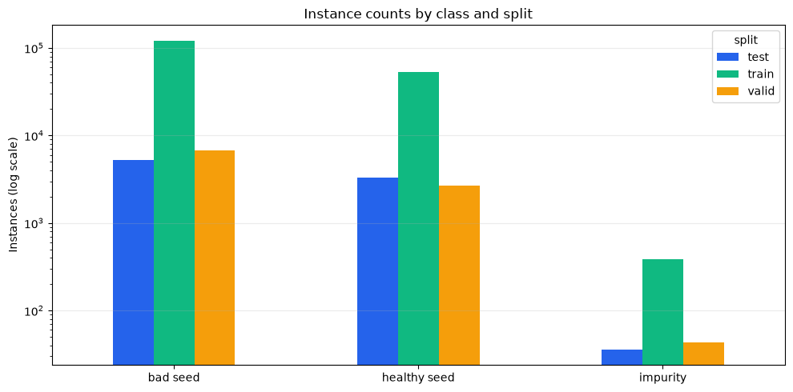

|  | training_images | single_class_images | mixed_class_images | single_class_percentage |
| --- | --- | --- | --- | --- |
| 0 | 2367 | 1767 | 600 | 74.65 |

```python
grain_counts = (
    report["class_counts"]
    .pivot(index="class_name", columns="split", values="instances")
    .reindex(index=CLASS_NAMES, columns=["train", "valid", "test"], fill_value=0)
    .fillna(0)
    .astype(int)
)
grain_counts["total"] = grain_counts.sum(axis=1)
grain_counts.loc["ALL LABELED INSTANCES"] = grain_counts.sum(axis=0)
display(grain_counts.style.format("{:,}").set_caption("Dataset V2 labeled instances"))
plot_class_balance(report["class_counts"], log_scale=True)

train_frame = report["per_image"].query("split == 'train'").copy()
class_matrix = train_frame[CLASS_NAMES].to_numpy()
active_classes = (class_matrix > 0).sum(axis=1)
train_frame["classes_present"] = active_classes
train_frame["single_class_image"] = active_classes == 1

purity_summary = pd.DataFrame({
    "training_images": [len(train_frame)],
    "single_class_images": [int(train_frame["single_class_image"].sum())],
    "mixed_class_images": [int((train_frame["classes_present"] > 1).sum())],
    "single_class_percentage": [round(100 * train_frame["single_class_image"].mean(), 2)],
})
display(purity_summary)
if purity_summary.loc[0, "single_class_percentage"] > 80:
    display(Markdown(
        "⚠️ **Background-bias risk:** more than 80% of training images contain only one class. "
        "Review the crop galleries and full images carefully; the model may learn camera/background cues."
    ))
```

## 7. Ground-truth crop gallery — review before training

These are labels from Dataset V2, not model predictions.

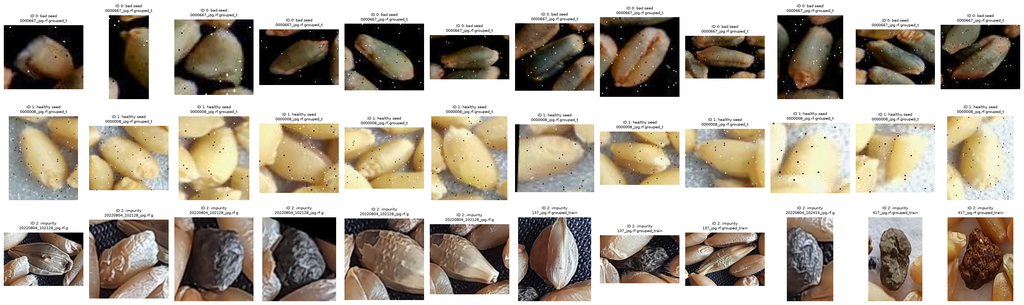

```python
IMAGE_SUFFIXES = (".jpg", ".jpeg", ".png", ".bmp", ".tif", ".tiff", ".webp")


def find_image(images_dir: Path, stem: str) -> Path | None:
    for suffix in IMAGE_SUFFIXES:
        candidate = images_dir / f"{stem}{suffix}"
        if candidate.exists():
            return candidate
    return None


def show_instance_crop_gallery(
    dataset_dir: Path,
    class_names: list[str],
    *,
    per_class: int = 12,
    seed: int = 23,
) -> None:
    labels_dir = dataset_dir / "train" / "labels"
    images_dir = dataset_dir / "train" / "images"
    label_paths = sorted(labels_dir.glob("*.txt"))
    random.Random(seed).shuffle(label_paths)
    samples: dict[int, list[tuple[Image.Image, str]]] = {
        class_id: [] for class_id in range(len(class_names))
    }

    for label_path in label_paths:
        if all(len(items) >= per_class for items in samples.values()):
            break
        image_path = find_image(images_dir, label_path.stem)
        if image_path is None:
            continue
        rows = []
        for line in label_path.read_text(encoding="utf-8").splitlines():
            tokens = line.split()
            if len(tokens) < 7 or (len(tokens) - 1) % 2:
                continue
            class_id = int(tokens[0])
            if class_id not in samples or len(samples[class_id]) >= per_class:
                continue
            coordinates = np.asarray([float(value) for value in tokens[1:]], dtype=np.float32).reshape(-1, 2)
            rows.append((class_id, coordinates))
        if not rows:
            continue

        with Image.open(image_path) as opened:
            image = opened.convert("RGB")
        width, height = image.size
        for class_id, coordinates in rows:
            x1 = int(np.floor(coordinates[:, 0].min() * width))
            y1 = int(np.floor(coordinates[:, 1].min() * height))
            x2 = int(np.ceil(coordinates[:, 0].max() * width))
            y2 = int(np.ceil(coordinates[:, 1].max() * height))
            padding = max(4, int(0.18 * max(x2 - x1, y2 - y1)))
            crop_box = (
                max(0, x1 - padding),
                max(0, y1 - padding),
                min(width, x2 + padding),
                min(height, y2 + padding),
            )
            crop = image.crop(crop_box)
            samples[class_id].append((crop, image_path.name))
            if len(samples[class_id]) >= per_class:
                continue

    figure, axes = plt.subplots(
        len(class_names),
        per_class,
        figsize=(2.25 * per_class, 2.7 * len(class_names)),
        squeeze=False,
    )
    for class_id, class_name in enumerate(class_names):
        assert samples[class_id], f"No crop samples found for class {class_id}: {class_name}"
        for column in range(per_class):
            axis = axes[class_id, column]
            if column < len(samples[class_id]):
                crop, filename = samples[class_id][column]
                axis.imshow(crop)
                axis.set_title(f"ID {class_id}: {class_name}\n{filename[:24]}", fontsize=7)
            axis.axis("off")
    plt.tight_layout()
    plt.show()


show_instance_crop_gallery(DATASET_DIR, CLASS_NAMES, per_class=12, seed=23)
```

Full training images containing class 0: `bad seed`

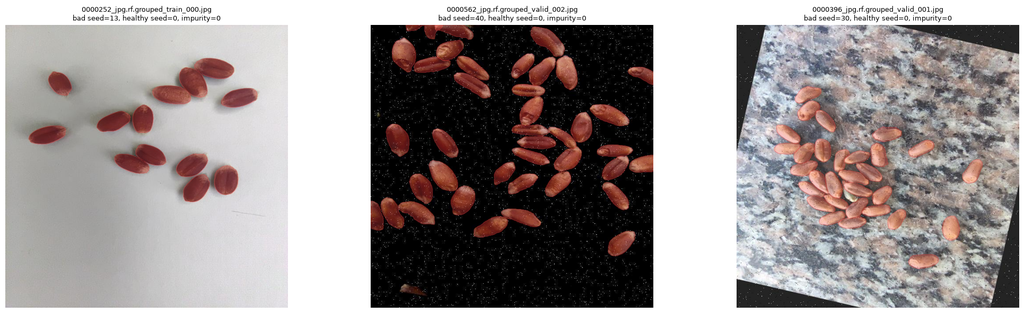

Full training images containing class 1: `healthy seed`

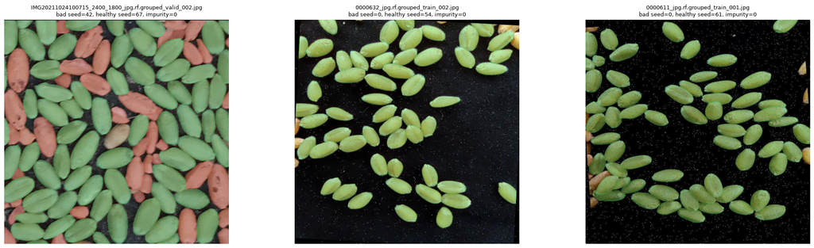

Full training images containing class 2: `impurity`

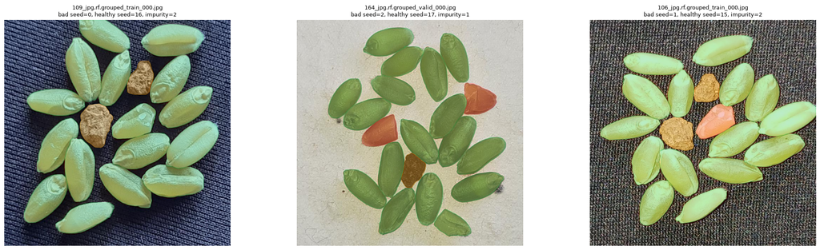

```python
for class_id, class_name in enumerate(CLASS_NAMES):
    display(Markdown(f"### Full training images containing class {class_id}: `{class_name}`"))
    plot_yolo_samples(DATASET_DIR, split="train", count=3, seed=31 + class_id, class_id=class_id, columns=3)
```

## 8. RF-DETR Segmentation Large capacity check and adaptive tiling

RF-DETR Segmentation Large has 200 object queries. When a source-safe image is too dense, the following cell creates an overlap-aware derived tiled dataset, clips the instance polygons to each crop, reruns the complete dataset audit, and only continues when every training tile is safely at or below 180 instances.

```python
MODEL_NUM_QUERIES = 200
TILE_TRIGGER_INSTANCES = 180
TILE_TARGET_INSTANCES = 140
TILE_OVERLAP_FRACTION = 0.08
TILING_VERSION = "adaptive-grid-v1"


def instance_density(audit_report: dict) -> pd.DataFrame:
    frame = audit_report["per_image"]
    table = frame.groupby("split")["instances"].agg(["count", "mean", "median", "max"])
    table["images_over_180"] = frame.groupby("split")["instances"].apply(
        lambda values: int((values > TILE_TRIGGER_INSTANCES).sum())
    )
    table["images_over_200"] = frame.groupby("split")["instances"].apply(
        lambda values: int((values > MODEL_NUM_QUERIES).sum())
    )
    return table


density_before_tiling = instance_density(report)
display(Markdown("### Density before adaptive tiling"))
display(density_before_tiling)

dense_train = int(
    (
        (report["per_image"]["split"] == "train")
        & (report["per_image"]["instances"] > MODEL_NUM_QUERIES)
    ).sum()
)


def read_yolo_segments(label_path: Path, width: int, height: int) -> list[dict]:
    segments = []
    for line_number, line in enumerate(label_path.read_text(encoding="utf-8").splitlines(), start=1):
        tokens = line.split()
        if not tokens:
            continue
        class_id = int(tokens[0])
        coordinates = np.asarray([float(value) for value in tokens[1:]], dtype=np.float64)
        assert len(coordinates) >= 6 and len(coordinates) % 2 == 0, (
            f"Invalid segmentation polygon at {label_path}:{line_number}"
        )
        points = coordinates.reshape(-1, 2)
        points[:, 0] *= width
        points[:, 1] *= height
        segments.append({"class_id": class_id, "points": points})
    return segments


def polygon_area(points: np.ndarray) -> float:
    if len(points) < 3:
        return 0.0
    x_coordinates = points[:, 0]
    y_coordinates = points[:, 1]
    return float(
        0.5
        * abs(
            np.dot(x_coordinates, np.roll(y_coordinates, 1))
            - np.dot(y_coordinates, np.roll(x_coordinates, 1))
        )
    )


def clip_polygon_to_rectangle(
    points: np.ndarray,
    left: float,
    top: float,
    right: float,
    bottom: float,
) -> np.ndarray:
    polygon = [tuple(map(float, point)) for point in points]

    def clip_edge(subject, inside, intersection):
        if not subject:
            return []
        output = []
        previous = subject[-1]
        previous_inside = inside(previous)
        for current in subject:
            current_inside = inside(current)
            if current_inside:
                if not previous_inside:
                    output.append(intersection(previous, current))
                output.append(current)
            elif previous_inside:
                output.append(intersection(previous, current))
            previous = current
            previous_inside = current_inside
        return output

    def intersect_vertical(first, second, x_value):
        delta_x = second[0] - first[0]
        ratio = 0.0 if abs(delta_x) < 1e-12 else (x_value - first[0]) / delta_x
        return (x_value, first[1] + ratio * (second[1] - first[1]))

    def intersect_horizontal(first, second, y_value):
        delta_y = second[1] - first[1]
        ratio = 0.0 if abs(delta_y) < 1e-12 else (y_value - first[1]) / delta_y
        return (first[0] + ratio * (second[0] - first[0]), y_value)

    polygon = clip_edge(
        polygon,
        lambda point: point[0] >= left,
        lambda first, second: intersect_vertical(first, second, left),
    )
    polygon = clip_edge(
        polygon,
        lambda point: point[0] <= right,
        lambda first, second: intersect_vertical(first, second, right),
    )
    polygon = clip_edge(
        polygon,
        lambda point: point[1] >= top,
        lambda first, second: intersect_horizontal(first, second, top),
    )
    polygon = clip_edge(
        polygon,
        lambda point: point[1] <= bottom,
        lambda first, second: intersect_horizontal(first, second, bottom),
    )

    if len(polygon) < 3:
        return np.empty((0, 2), dtype=np.float64)

    cleaned = []
    for point in polygon:
        if not cleaned or np.linalg.norm(np.asarray(point) - np.asarray(cleaned[-1])) > 1e-6:
            cleaned.append(point)
    if len(cleaned) > 1 and np.linalg.norm(np.asarray(cleaned[0]) - np.asarray(cleaned[-1])) <= 1e-6:
        cleaned.pop()
    if len(cleaned) < 3:
        return np.empty((0, 2), dtype=np.float64)
    return np.asarray(cleaned, dtype=np.float64)


def make_tile_plan(
    width: int,
    height: int,
    segments: list[dict],
    grid_size: int,
) -> list[dict]:
    plan = []
    for row in range(grid_size):
        core_top = round(row * height / grid_size)
        core_bottom = round((row + 1) * height / grid_size)
        cell_height = core_bottom - core_top
        vertical_padding = round(cell_height * TILE_OVERLAP_FRACTION)
        top = max(0, core_top - vertical_padding)
        bottom = min(height, core_bottom + vertical_padding)

        for column in range(grid_size):
            core_left = round(column * width / grid_size)
            core_right = round((column + 1) * width / grid_size)
            cell_width = core_right - core_left
            horizontal_padding = round(cell_width * TILE_OVERLAP_FRACTION)
            left = max(0, core_left - horizontal_padding)
            right = min(width, core_right + horizontal_padding)

            tile_segments = []
            for segment_index, segment in enumerate(segments):
                original_area = polygon_area(segment["points"])
                clipped = clip_polygon_to_rectangle(
                    segment["points"], left, top, right, bottom
                )
                clipped_area = polygon_area(clipped)
                if (
                    len(clipped) >= 3
                    and clipped_area >= 0.5
                    and clipped_area >= 0.05 * max(original_area, 1e-9)
                ):
                    tile_segments.append({
                        "segment_index": segment_index,
                        "class_id": segment["class_id"],
                        "points": clipped,
                    })
```

```python
            if tile_segments:
                plan.append({
                    "row": row,
                    "column": column,
                    "bounds": (left, top, right, bottom),
                    "segments": tile_segments,
                })
    return plan


def choose_tile_plan(width: int, height: int, segments: list[dict]) -> tuple[int, list[dict]]:
    initial_grid = max(2, int(np.ceil(np.sqrt(len(segments) / TILE_TARGET_INSTANCES))))
    for grid_size in range(initial_grid, 13):
        plan = make_tile_plan(width, height, segments, grid_size)
        maximum_instances = max((len(tile["segments"]) for tile in plan), default=0)
        covered_segments = {
            item["segment_index"]
            for tile in plan
            for item in tile["segments"]
        }
        if maximum_instances <= TILE_TRIGGER_INSTANCES and len(covered_segments) == len(segments):
            return grid_size, plan
    raise RuntimeError(
        f"Could not produce <= {TILE_TRIGGER_INSTANCES}-instance tiles for an image "
        f"containing {len(segments)} annotations."
    )


def write_tile_label(label_path: Path, tile: dict) -> None:
    left, top, right, bottom = tile["bounds"]
    tile_width = right - left
    tile_height = bottom - top
    lines = []
    for segment in tile["segments"]:
        normalized = segment["points"].copy()
        normalized[:, 0] = np.clip((normalized[:, 0] - left) / tile_width, 0.0, 1.0)
        normalized[:, 1] = np.clip((normalized[:, 1] - top) / tile_height, 0.0, 1.0)
        coordinates = " ".join(f"{value:.6f}" for value in normalized.reshape(-1))
        lines.append(f"{segment['class_id']} {coordinates}")
    label_path.write_text("\n".join(lines) + "\n", encoding="utf-8")


if dense_train:
    tiling_signature = hashlib.sha256(
        (
            f"{DATASET_FINGERPRINT}|{TILING_VERSION}|{TILE_TRIGGER_INSTANCES}|"
            f"{TILE_TARGET_INSTANCES}|{TILE_OVERLAP_FRACTION}"
        ).encode("utf-8")
    ).hexdigest()
    TILED_DATASET_DIR = RUN_ROOT / f"dataset_v2_grouped_tiled_{tiling_signature[:12]}"
    TILED_BUILD_DIR = RUN_ROOT / f".{TILED_DATASET_DIR.name}.building"
    TILED_MARKER = TILED_DATASET_DIR / "adaptive_tiling_manifest.json"

    if TILED_DATASET_DIR.exists() and not TILED_MARKER.exists():
        raise RuntimeError(
            f"Tiled dataset exists without a completion marker: {TILED_DATASET_DIR}. "
            "Move this incomplete derived directory aside and rerun the cell."
        )

    if not TILED_MARKER.exists():
        if TILED_BUILD_DIR.exists():
            shutil.rmtree(TILED_BUILD_DIR)
        for split_name in ("train", "valid", "test"):
            (TILED_BUILD_DIR / split_name / "images").mkdir(parents=True, exist_ok=True)
            (TILED_BUILD_DIR / split_name / "labels").mkdir(parents=True, exist_ok=True)

        def materialize_unchanged(source: Path, destination: Path) -> None:
            try:
                os.symlink(source.resolve(), destination)
            except OSError:
                shutil.copy2(source, destination)

        tiling_rows = []
        image_suffixes = {".jpg", ".jpeg", ".png", ".bmp", ".tif", ".tiff", ".webp"}
        for split_name in ("train", "valid", "test"):
            source_images = DATASET_DIR / split_name / "images"
            source_labels = DATASET_DIR / split_name / "labels"
            target_images = TILED_BUILD_DIR / split_name / "images"
            target_labels = TILED_BUILD_DIR / split_name / "labels"

            for image_path in sorted(source_images.iterdir()):
                if not image_path.is_file() or image_path.suffix.lower() not in image_suffixes:
                    continue
                label_path = source_labels / f"{image_path.stem}.txt"
                with Image.open(image_path) as opened:
                    width, height = opened.size
                    segments = read_yolo_segments(label_path, width, height)

                    if len(segments) <= TILE_TRIGGER_INSTANCES:
                        materialize_unchanged(image_path, target_images / image_path.name)
                        materialize_unchanged(label_path, target_labels / label_path.name)
                        tiling_rows.append({
                            "split": split_name,
                            "source_image": image_path.name,
                            "source_instances": len(segments),
                            "grid_size": 1,
                            "tiles_written": 1,
                            "maximum_tile_instances": len(segments),
                        })
                        continue

                    rgb_image = opened.convert("RGB")
                    grid_size, tile_plan = choose_tile_plan(width, height, segments)
                    source_id = source_id_from_stem(image_path.stem)
                    record_token = hashlib.sha1(image_path.name.encode("utf-8")).hexdigest()[:10]
                    for tile in tile_plan:
                        tile_stem = (
                            f"{source_id}.rf.tile_{record_token}_g{grid_size}_"
                            f"r{tile['row']:02d}_c{tile['column']:02d}"
                        )
                        image_output = target_images / f"{tile_stem}.jpg"
                        label_output = target_labels / f"{tile_stem}.txt"
                        rgb_image.crop(tile["bounds"]).save(
                            image_output,
                            format="JPEG",
                            quality=95,
                            subsampling=0,
                        )
                        write_tile_label(label_output, tile)

                    tiling_rows.append({
                        "split": split_name,
                        "source_image": image_path.name,
                        "source_instances": len(segments),
                        "grid_size": grid_size,
                        "tiles_written": len(tile_plan),
                        "maximum_tile_instances": max(
                            len(tile["segments"]) for tile in tile_plan
                        ),
                    })
```

```python
        tiled_config = {
            "train": "train/images",
            "val": "valid/images",
            "test": "test/images",
            "nc": len(EXPECTED_CLASS_NAMES),
            "names": EXPECTED_CLASS_NAMES,
        }
        with (TILED_BUILD_DIR / "data.yaml").open("w", encoding="utf-8") as handle:
            yaml.safe_dump(tiled_config, handle, sort_keys=False, allow_unicode=True)

        tiling_frame = pd.DataFrame(tiling_rows)
        tiling_frame.to_csv(REPORT_DIR / "adaptive_tiling_manifest.csv", index=False)
        marker_payload = {
            "source_dataset": str(DATASET_DIR),
            "source_fingerprint": DATASET_FINGERPRINT,
            "tiling_version": TILING_VERSION,
            "trigger_instances": TILE_TRIGGER_INSTANCES,
            "target_instances": TILE_TARGET_INSTANCES,
            "overlap_fraction": TILE_OVERLAP_FRACTION,
            "source_images": int(len(tiling_frame)),
            "materialized_images": int(tiling_frame["tiles_written"].sum()),
            "tiled_source_images": int((tiling_frame["grid_size"] > 1).sum()),
            "maximum_tile_instances": int(tiling_frame["maximum_tile_instances"].max()),
        }
        (TILED_BUILD_DIR / "adaptive_tiling_manifest.json").write_text(
            json.dumps(marker_payload, indent=2, sort_keys=True) + "\n",
            encoding="utf-8",
        )
        TILED_BUILD_DIR.rename(TILED_DATASET_DIR)
        print(f"Created adaptive tiled dataset: {TILED_DATASET_DIR}")
    else:
        print(f"Reusing completed adaptive tiled dataset: {TILED_DATASET_DIR}")

    DATASET_DIR = TILED_DATASET_DIR
    normalized_yaml = DATASET_DIR / "data.yaml"
    report = audit_dataset(DATASET_DIR, deep_coordinate_check=True)
    CLASS_NAMES = report["class_names"]

    if not report["issues"].empty:
        display(report["issues"].head(100))
    assert report["issues"].empty, (
        f"TILING SAFETY STOP: {len(report['issues'])} tile label issues were detected."
    )
    tiled_leakage = report["source_overlaps"]
    tiled_leakage = tiled_leakage[tiled_leakage["likely_shared_sources"] > 0]
    assert tiled_leakage.empty, "TILING SAFETY STOP: source leakage appeared after tiling."

    density = instance_density(report)
    display(Markdown("### Density after adaptive tiling"))
    display(report["summary"])
    display(report["class_counts"])
    display(density)

    report["summary"].to_csv(REPORT_DIR / "tiled_dataset_summary.csv", index=False)
    report["class_counts"].to_csv(REPORT_DIR / "tiled_class_counts.csv", index=False)
    report["issues"].to_csv(REPORT_DIR / "tiled_dataset_issues.csv", index=False)
    report["source_overlaps"].to_csv(REPORT_DIR / "tiled_source_overlaps.csv", index=False)

    tiled_dense_train = int(
        (
            (report["per_image"]["split"] == "train")
            & (report["per_image"]["instances"] > MODEL_NUM_QUERIES)
        ).sum()
    )
    assert tiled_dense_train == 0, (
        f"TILING SAFETY STOP: {tiled_dense_train} training tiles still exceed "
        f"Large's {MODEL_NUM_QUERIES}-query limit."
    )
    assert int(density.loc["train", "max"]) <= TILE_TRIGGER_INSTANCES

    tiled_fingerprint = hashlib.sha256()
    tiled_fingerprint.update(normalized_yaml.read_bytes())
    for path in sorted(DATASET_DIR.rglob("*")):
        if not path.is_file() or path.name.endswith(".cache"):
            continue
        relative = path.relative_to(DATASET_DIR).as_posix()
        tiled_fingerprint.update(relative.encode("utf-8"))
        tiled_fingerprint.update(str(path.stat().st_size).encode("ascii"))
        if path.suffix.lower() == ".txt":
            tiled_fingerprint.update(path.read_bytes())
    DATASET_FINGERPRINT = tiled_fingerprint.hexdigest()
    (REPORT_DIR / "training_dataset_fingerprint.txt").write_text(
        DATASET_FINGERPRINT + "\n",
        encoding="utf-8",
    )
    print(f"Training will use tiled dataset: {DATASET_DIR}")
    print(f"Tiled dataset fingerprint: {DATASET_FINGERPRINT}")
else:
    density = density_before_tiling
    print("No training image exceeds Large's 200-query capacity; tiling is not required.")

print("RF-DETR Segmentation Large capacity check passed.")
```

Density before adaptive tiling

| split | count | mean | median | max | images_over_180 | images_over_200 |
| --- | --- | --- | --- | --- | --- | --- |
| test | 126 | 68.579365 | 50.5 | 465 | 7 | 7 |
| train | 2367 | 73.825518 | 51.0 | 614 | 196 | 148 |
| valid | 126 | 75.301587 | 51.0 | 616 | 11 | 8 |

```
Reusing completed adaptive tiled dataset: /home/multispector2/testdino/outputRFDetrV2/dataset_v2_grouped_tiled_553f62ae5065
```

Density after adaptive tiling

|  | split | images | instances | instances/image mean | instances/image p95 | instances/image max | images > 100 instances |
| --- | --- | --- | --- | --- | --- | --- | --- |
| 0 | train | 3113 | 200606 | 64.4 | 140 | 180 | 615 |
| 1 | valid | 169 | 10947 | 64.8 | 137 | 174 | 35 |
| 2 | test | 156 | 9524 | 61.1 | 129 | 177 | 28 |

|  | split | class_id | class_name | instances | percentage |
| --- | --- | --- | --- | --- | --- |
| 0 | train | 0 | bad seed | 141911 | 70.741 |
| 1 | train | 1 | healthy seed | 58308 | 29.066 |
| 2 | train | 2 | impurity | 387 | 0.193 |
| 3 | valid | 0 | bad seed | 7902 | 72.184 |
| 4 | valid | 1 | healthy seed | 3002 | 27.423 |
| 5 | valid | 2 | impurity | 43 | 0.393 |
| 6 | test | 0 | bad seed | 5796 | 60.857 |
| 7 | test | 1 | healthy seed | 3692 | 38.765 |
| 8 | test | 2 | impurity | 36 | 0.378 |

| split | count | mean | median | max | images_over_180 | images_over_200 |
| --- | --- | --- | --- | --- | --- | --- |
| test | 156 | 61.051282 | 55.5 | 177 | 0 | 0 |
| train | 3113 | 64.441375 | 59.0 | 180 | 0 | 0 |
| valid | 169 | 64.775148 | 59.0 | 174 | 0 | 0 |

```
Training will use tiled dataset: /home/multispector2/testdino/outputRFDetrV2/dataset_v2_grouped_tiled_553f62ae5065
Tiled dataset fingerprint: 3ce3621beb544950fda52561ed64e9469fe9c05e563898d75fef33a762fba83b
RF-DETR Segmentation Large capacity check passed.
```

## 9. Training configuration for the 20GB RTX 4000 server GPU

```python
RESOLUTION = 504
BATCH_SIZE = 1
GRAD_ACCUM_STEPS = 16
SMOKE_EPOCHS = 1
FULL_EPOCHS = 50
LEARNING_RATE = 1e-4
BACKBONE_LEARNING_RATE = 5e-5
NUM_WORKERS = 4
GRADIENT_CHECKPOINTING = True
GROUP_DETR = 1  # 20GB safety: avoids 13x duplicated training queries/mask targets.

config_table = pd.DataFrame({
    "parameter": [
        "model", "resolution", "queries", "batch_size", "grad_accum_steps",
        "effective_batch", "smoke_epochs", "full_epochs", "lr", "lr_encoder",
        "num_workers", "gradient_checkpointing", "group_detr",
    ],
    "value": [
        "RFDETRSegLarge", RESOLUTION, MODEL_NUM_QUERIES, BATCH_SIZE, GRAD_ACCUM_STEPS,
        BATCH_SIZE * GRAD_ACCUM_STEPS, SMOKE_EPOCHS, FULL_EPOCHS, LEARNING_RATE,
        BACKBONE_LEARNING_RATE, NUM_WORKERS, GRADIENT_CHECKPOINTING, GROUP_DETR,
    ],
})
display(config_table)
```

|  | parameter | value |
| --- | --- | --- |
| 0 | model | RFDETRSegLarge |
| 1 | resolution | 504 |
| 2 | queries | 200 |
| 3 | batch_size | 1 |
| 4 | grad_accum_steps | 16 |
| 5 | effective_batch | 16 |
| 6 | smoke_epochs | 1 |
| 7 | full_epochs | 50 |
| 8 | lr | 0.0001 |
| 9 | lr_encoder | 0.00005 |
| 10 | num_workers | 4 |
| 11 | gradient_checkpointing | True |
| 12 | group_detr | 1 |

## 10. One-epoch Large smoke test

This validates VRAM, data loading, all three classes, and checkpoint writing before the full run.

```python
from rfdetr import RFDETRSegLarge

smoke_model = RFDETRSegLarge(
    num_classes=len(CLASS_NAMES),
    resolution=RESOLUTION,
    gradient_checkpointing=GRADIENT_CHECKPOINTING,
    group_detr=GROUP_DETR,
)
print(f"Smoke model loaded: {type(smoke_model).__name__}")
print(f"Resolution: {smoke_model.model_config.resolution}")
print(f"Queries: {smoke_model.model_config.num_queries}")
print(f"Classes: {CLASS_NAMES}")
```

```
[2026-08-25 21:50:26] [INFO] rf-detr - File /home/multispector2/.roboflow/models/rf-detr-seg-large.pt already exists with correct MD5 hash.
```

```
[2026-08-25 21:50:26] [WARNING] rf-detr - Using a different number of positional encodings than DINOv2, which means we're not loading DINOv2 backbone weights. This is not a problem if finetuning a pretrained RF-DETR model.
[2026-08-25 21:50:26] [WARNING] rf-detr - Using patch size 12 instead of 14, which means we're not loading DINOv2 backbone weights. This is not a problem if finetuning a pretrained RF-DETR model.
```

```
[2026-08-25 21:50:27] [INFO] rf-detr - File /home/multispector2/.roboflow/models/rf-detr-seg-large.pt already exists with correct MD5 hash.
```

[output not shown]

```
Smoke model loaded: RFDETRSegLarge
Resolution: 504
Queries: 200
Classes: ['bad seed', 'healthy seed', 'impurity']
```

```python
smoke_model.train(
    dataset_dir=str(DATASET_DIR),
    output_dir=str(SMOKE_DIR),
    device="cuda",
    resolution=RESOLUTION,
    epochs=SMOKE_EPOCHS,
    batch_size=BATCH_SIZE,
    grad_accum_steps=GRAD_ACCUM_STEPS,
    lr=LEARNING_RATE,
    lr_encoder=BACKBONE_LEARNING_RATE,
    num_workers=NUM_WORKERS,
    use_ema=False,
    early_stopping=False,
    checkpoint_interval=1,
    run_test=False,
    log_per_class_metrics=True,
    compute_val_loss=True,
    scale_jitter=True,
    save_dataset_grids=True,
)

SMOKE_CHECKPOINT = SMOKE_DIR / "checkpoint_best_regular.pth"
assert SMOKE_CHECKPOINT.exists(), f"Smoke checkpoint was not created: {SMOKE_CHECKPOINT}"
print(f"Smoke test passed: {SMOKE_CHECKPOINT}")

del smoke_model
gc.collect()
torch.cuda.empty_cache()
print(f"GPU memory after smoke cleanup: {torch.cuda.memory_allocated() / 1024**3:.2f} GB")
```

[output not shown]

```python
from rfdetr import RFDETRSegLarge

model = RFDETRSegLarge(
    num_classes=len(CLASS_NAMES),
    resolution=RESOLUTION,
    gradient_checkpointing=GRADIENT_CHECKPOINTING,
    group_detr=GROUP_DETR,
)
print(f"Full model loaded: {type(model).__name__}")
print(f"Training query groups: {model.model_config.group_detr}")
assert model.model_config.group_detr == 1
print(f"Full training outputs: {TRAIN_DIR}")
```

```
[2026-08-25 21:50:49] [INFO] rf-detr - File /home/multispector2/.roboflow/models/rf-detr-seg-large.pt already exists with correct MD5 hash.
```

```
[2026-08-25 21:50:49] [WARNING] rf-detr - Using a different number of positional encodings than DINOv2, which means we're not loading DINOv2 backbone weights. This is not a problem if finetuning a pretrained RF-DETR model.
[2026-08-25 21:50:49] [WARNING] rf-detr - Using patch size 12 instead of 14, which means we're not loading DINOv2 backbone weights. This is not a problem if finetuning a pretrained RF-DETR model.
```

```
[2026-08-25 21:50:50] [INFO] rf-detr - File /home/multispector2/.roboflow/models/rf-detr-seg-large.pt already exists with correct MD5 hash.
```

[output not shown]

```
Full model loaded: RFDETRSegLarge
Training query groups: 1
Full training outputs: /home/multispector2/testdino/outputRFDetrV2/training
```

```python
gc.collect()
torch.cuda.empty_cache()
torch.cuda.reset_peak_memory_stats()

model.train(
    dataset_dir=str(DATASET_DIR),
    output_dir=str(TRAIN_DIR),
    device="cuda",
    resolution=RESOLUTION,
    epochs=FULL_EPOCHS,
    batch_size=BATCH_SIZE,
    grad_accum_steps=GRAD_ACCUM_STEPS,
    lr=LEARNING_RATE,
    lr_encoder=BACKBONE_LEARNING_RATE,
    num_workers=NUM_WORKERS,
    use_ema=False,
    early_stopping=False,
    checkpoint_interval=1,
    run_test=False,
    log_per_class_metrics=True,
    compute_val_loss=True,
    scale_jitter=True,
    save_dataset_grids=True,
)

BEST_CHECKPOINT = TRAIN_DIR / "checkpoint_best_regular.pth"
assert BEST_CHECKPOINT.exists(), f"Best checkpoint was not created: {BEST_CHECKPOINT}"
print(f"Best validation checkpoint: {BEST_CHECKPOINT}")
```

```
                       Val (Epoch 50/50) — Overall Metrics
┏━━━━━━━━━━━━━━━━━━━━━━━━━━┳━━━━━━━━┳━━━━━━━━━━━━━━━━━━━━━━━━━━┳━━━━━━━━━━━━━━━━━┓
┃           mAP            ┃  mAR   ┃         F1 sweep         ┃     segm mAP    ┃
┡━━━━━━━━┯━━━━━━━━┯━━━━━━━━╇━━━━━━━━╇━━━━━━━━┯━━━━━━━━┯━━━━━━━━╇━━━━━━━━┯━━━━━━━━┩
│ 50:95  │   50   │   75   │  @500  │   F1   │  Prec  │ Recall │ 50:95  │   50   │
├────────┼────────┼────────┼────────┼────────┼────────┼────────┼────────┼────────┤
│ 0.8684 │ 0.9668 │ 0.9389 │ 0.9033 │ 0.9249 │ 0.9139 │ 0.9363 │ 0.7892 │ 0.9637 │
└────────┴────────┴────────┴────────┴────────┴────────┴────────┴────────┴────────┘
              Val (Epoch 50/50) — Per-class Metrics
┏━━━━━━━━━━━━━━┳━━━━━━━━━━┳━━━━━━━━┳━━━━━━━━┳━━━━━━━━━━━┳━━━━━━━━┓
┃ Class        ┃ AP 50:95 ┃     AR ┃     F1 ┃ Precision ┃ Recall ┃
┡━━━━━━━━━━━━━━╇━━━━━━━━━━╇━━━━━━━━╇━━━━━━━━╇━━━━━━━━━━━╇━━━━━━━━┩
│ bad seed     │   0.8106 │ 0.8515 │ 0.9198 │    0.9048 │ 0.9353 │
│ healthy seed │   0.8759 │ 0.9141 │ 0.9125 │    0.9050 │ 0.9201 │
│ impurity     │   0.9185 │ 0.9442 │ 0.9425 │    0.9318 │ 0.9535 │
└──────────────┴──────────┴────────┴────────┴───────────┴────────┘
```

```
`Trainer.fit` stopped: `max_epochs=50` reached.
```

```
[2026-08-26 10:16:40] [INFO] rf-detr - Best total checkpoint saved from regular (regular=0.7933, ema=0.0000)
Best validation checkpoint: /home/multispector2/testdino/outputRFDetrV2/training/checkpoint_best_regular.pth
```

## 12. Training curves, best-checkpoint reload, and official Test metrics

```python
metrics_path = TRAIN_DIR / "metrics.csv"
if metrics_path.exists():
    metrics_frame = pd.read_csv(metrics_path)
    display(metrics_frame.tail())
    preferred_columns = [
        "train/loss", "val/loss", "val/mAP_50_95", "val/segm_mAP_50_95",
        "val/F1", "val/precision", "val/recall",
        *[f"val/AP/{class_name}" for class_name in CLASS_NAMES],
    ]
    curve_columns = [
        column for column in preferred_columns
        if column in metrics_frame.columns and metrics_frame[column].notna().any()
    ]
    if curve_columns:
        selected = (["epoch"] if "epoch" in metrics_frame.columns else []) + curve_columns
        plot_frame = metrics_frame[selected].copy()
        if "epoch" in plot_frame.columns:
            plot_frame = plot_frame.groupby("epoch", as_index=False).last()
        plot_frame = plot_frame.dropna(subset=curve_columns, how="all")
        plot_frame.plot(
            x="epoch" if "epoch" in plot_frame.columns else None,
            y=curve_columns,
            subplots=True,
            figsize=(12, 2.7 * len(curve_columns)),
            grid=True,
            marker="o",
        )
        plt.tight_layout()
        plt.show()
else:
    print(f"No metrics.csv found at {metrics_path}")

print(f"Loading best Large V2 checkpoint: {BEST_CHECKPOINT}")
model = RFDETRSegLarge.from_checkpoint(str(BEST_CHECKPOINT), trust_checkpoint=True)

test_metrics = model.evaluate(
    dataset_dir=str(DATASET_DIR),
    split="test",
    device="cuda",
    batch_size=1,
)
test_metrics_frame = pd.DataFrame(test_metrics.items(), columns=["metric", "value"])
display(test_metrics_frame)
test_metrics_frame.to_csv(REPORT_DIR / "test_metrics.csv", index=False)
```

[output not shown]

```
                       Test (Epoch 1/100) — Overall Metrics
┏━━━━━━━━━━━━━━━━━━━━━━━━━━┳━━━━━━━━┳━━━━━━━━━━━━━━━━━━━━━━━━━━┳━━━━━━━━━━━━━━━━━┓
┃           mAP            ┃  mAR   ┃         F1 sweep         ┃     segm mAP    ┃
┡━━━━━━━━┯━━━━━━━━┯━━━━━━━━╇━━━━━━━━╇━━━━━━━━┯━━━━━━━━┯━━━━━━━━╇━━━━━━━━┯━━━━━━━━┩
│ 50:95  │   50   │   75   │  @500  │   F1   │  Prec  │ Recall │ 50:95  │   50   │
├────────┼────────┼────────┼────────┼────────┼────────┼────────┼────────┼────────┤
│ 0.8273 │ 0.9177 │ 0.8837 │ 0.8617 │ 0.9125 │ 0.9499 │ 0.8845 │ 0.7600 │ 0.9166 │
└────────┴────────┴────────┴────────┴────────┴────────┴────────┴────────┴────────┘
              Test (Epoch 1/100) — Per-class Metrics
┏━━━━━━━━━━━━━━┳━━━━━━━━━━┳━━━━━━━━┳━━━━━━━━┳━━━━━━━━━━━┳━━━━━━━━┓
┃ Class        ┃ AP 50:95 ┃     AR ┃     F1 ┃ Precision ┃ Recall ┃
┡━━━━━━━━━━━━━━╇━━━━━━━━━━╇━━━━━━━━╇━━━━━━━━╇━━━━━━━━━━━╇━━━━━━━━┩
│ bad seed     │   0.8492 │ 0.8881 │ 0.9353 │    0.9257 │ 0.9451 │
│ healthy seed │   0.8500 │ 0.8887 │ 0.9273 │    0.9239 │ 0.9307 │
│ impurity     │   0.7828 │ 0.8083 │ 0.8750 │    1.0000 │ 0.7778 │
└──────────────┴──────────┴────────┴────────┴───────────┴────────┘
```

```
┏━━━━━━━━━━━━━━━━━━━━━━━━━━━┳━━━━━━━━━━━━━━━━━━━━━━━━━━━┓
┃        Test metric        ┃       DataLoader 0        ┃
┡━━━━━━━━━━━━━━━━━━━━━━━━━━━╇━━━━━━━━━━━━━━━━━━━━━━━━━━━┩
│     test/AP/bad seed      │    0.8491716980934143     │
│   test/AP/healthy seed    │    0.8500082492828369     │
│     test/AP/impurity      │    0.7827926278114319     │
│          test/F1          │    0.9125204682350159     │
│         test/loss         │     5.031124591827393     │
│        test/mAP_50        │    0.9176813960075378     │
│      test/mAP_50_95       │    0.8273242115974426     │
│        test/mAP_75        │    0.8836618661880493     │
│         test/mAR          │    0.8617260456085205     │
│      test/precision       │    0.9498516321182251     │
│        test/recall        │     0.884524405002594     │
│     test/segm_mAP_50      │    0.9166175127029419     │
│    test/segm_mAP_50_95    │    0.7599650025367737     │
└───────────────────────────┴───────────────────────────┘
```

|  | metric | value |
| --- | --- | --- |
| 0 | test/loss | 5.031125 |
| 1 | test/mAP_50_95 | 0.827324 |
| 2 | test/mAP_50 | 0.917681 |
| 3 | test/mAP_75 | 0.883662 |
| 4 | test/mAR | 0.861726 |
| 5 | test/segm_mAP_50_95 | 0.759965 |
| 6 | test/segm_mAP_50 | 0.916618 |
| 7 | test/F1 | 0.912520 |
| 8 | test/precision | 0.949852 |
| 9 | test/recall | 0.884524 |
| 10 | test/AP/bad seed | 0.849172 |
| 11 | test/AP/healthy seed | 0.850008 |
| 12 | test/AP/impurity | 0.782793 |

## 13. Matched-instance classification confusion matrix

This supplements mAP with an actual classification check after matching predictions to ground truth at box IoU ≥ 0.50.

```
[2026-08-26 10:19:25] [WARNING] rf-detr - Model is not optimized for inference. Latency may be higher than expected. For full GPU throughput (e.g. ~8x on T4 via FP16 Tensor Cores), call model.inference(dtype=torch.float16).
```

```
Matched-classification progress: 25/156 images
Matched-classification progress: 50/156 images
Matched-classification progress: 75/156 images
Matched-classification progress: 100/156 images
Matched-classification progress: 125/156 images
Matched-classification progress: 150/156 images
Matched-classification progress: 156/156 images
```

| Prediction Ground truth | bad seed | healthy seed | impurity |
| --- | --- | --- | --- |
| bad seed | 5480 | 77 | 1 |
| healthy seed | 1937 | 1675 | 0 |
| impurity | 1 | 6 | 26 |

```
Matched-instance classification accuracy: 78.03%
Matched instances: 9,203 / 9,524 ground-truth instances
Detection-aware correctly classified GT share: 75.40%
Predictions at threshold 0.35: 10,739
```

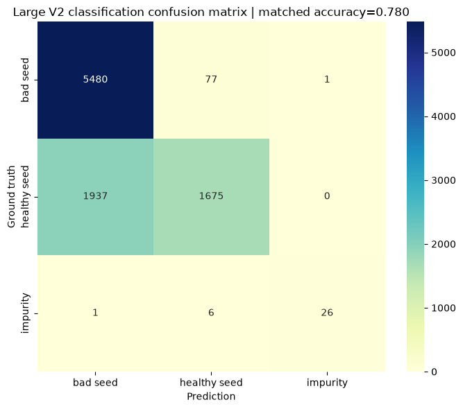

```python
def load_yolo_polygon_boxes(label_path: Path, width: int, height: int):
    boxes, class_ids = [], []
    for line in label_path.read_text(encoding="utf-8").splitlines():
        tokens = line.split()
        if len(tokens) < 7 or (len(tokens) - 1) % 2:
            continue
        class_id = int(tokens[0])
        points = np.asarray([float(value) for value in tokens[1:]], dtype=np.float32).reshape(-1, 2)
        boxes.append([
            points[:, 0].min() * width,
            points[:, 1].min() * height,
            points[:, 0].max() * width,
            points[:, 1].max() * height,
        ])
        class_ids.append(class_id)
    return np.asarray(boxes, dtype=np.float32), np.asarray(class_ids, dtype=np.int64)


def box_iou_matrix(first: np.ndarray, second: np.ndarray) -> np.ndarray:
    if len(first) == 0 or len(second) == 0:
        return np.zeros((len(first), len(second)), dtype=np.float32)
    top_left = np.maximum(first[:, None, :2], second[None, :, :2])
    bottom_right = np.minimum(first[:, None, 2:], second[None, :, 2:])
    intersection_wh = np.clip(bottom_right - top_left, 0, None)
    intersection = intersection_wh[..., 0] * intersection_wh[..., 1]
    first_area = np.clip(first[:, 2] - first[:, 0], 0, None) * np.clip(first[:, 3] - first[:, 1], 0, None)
    second_area = np.clip(second[:, 2] - second[:, 0], 0, None) * np.clip(second[:, 3] - second[:, 1], 0, None)
    union = first_area[:, None] + second_area[None, :] - intersection
    return intersection / np.maximum(union, 1e-9)


test_images_dir = DATASET_DIR / "test" / "images"
test_labels_dir = DATASET_DIR / "test" / "labels"
test_image_paths = sorted(
    path for path in test_images_dir.iterdir()
    if path.suffix.lower() in IMAGE_SUFFIXES
)

y_true, y_pred = [], []
total_gt = total_predictions = matched_instances = 0
for image_index, image_path in enumerate(test_image_paths, start=1):
    image_bgr = cv2.imread(str(image_path))
    if image_bgr is None:
        continue
    height, width = image_bgr.shape[:2]
    gt_boxes, gt_classes = load_yolo_polygon_boxes(test_labels_dir / f"{image_path.stem}.txt", width, height)
    detections = model.predict(image_bgr, threshold=0.35)
    pred_boxes = np.asarray(detections.xyxy, dtype=np.float32)
    pred_classes = np.asarray(detections.class_id, dtype=np.int64)
    ious = box_iou_matrix(gt_boxes, pred_boxes)

    candidate_pairs = np.argwhere(ious >= 0.50)
    candidate_pairs = sorted(candidate_pairs, key=lambda pair: ious[pair[0], pair[1]], reverse=True)
    used_gt, used_pred = set(), set()
    for gt_index, pred_index in candidate_pairs:
        gt_index, pred_index = int(gt_index), int(pred_index)
        if gt_index in used_gt or pred_index in used_pred:
            continue
        used_gt.add(gt_index)
        used_pred.add(pred_index)
        y_true.append(int(gt_classes[gt_index]))
        y_pred.append(int(pred_classes[pred_index]))

    total_gt += len(gt_classes)
    total_predictions += len(pred_classes)
    matched_instances += len(used_gt)
    if image_index % 25 == 0 or image_index == len(test_image_paths):
        print(f"Matched-classification progress: {image_index}/{len(test_image_paths)} images")

assert matched_instances > 0, "No GT/prediction matches found at IoU >= 0.50."
confusion = pd.crosstab(
    pd.Categorical.from_codes(y_true, CLASS_NAMES),
    pd.Categorical.from_codes(y_pred, CLASS_NAMES),
    rownames=["Ground truth"],
    colnames=["Prediction"],
    dropna=False,
).reindex(index=CLASS_NAMES, columns=CLASS_NAMES, fill_value=0)

matched_accuracy = float(np.mean(np.asarray(y_true) == np.asarray(y_pred)))
detection_aware_correct = int(np.sum(np.asarray(y_true) == np.asarray(y_pred))) / max(total_gt, 1)

display(confusion)
print(f"Matched-instance classification accuracy: {matched_accuracy * 100:.2f}%")
print(f"Matched instances: {matched_instances:,} / {total_gt:,} ground-truth instances")
print(f"Detection-aware correctly classified GT share: {detection_aware_correct * 100:.2f}%")
print(f"Predictions at threshold 0.35: {total_predictions:,}")

plt.figure(figsize=(7, 6))
sns.heatmap(confusion, annot=True, fmt="d", cmap="YlGnBu")
plt.title(f"Large V2 classification confusion matrix | matched accuracy={matched_accuracy:.3f}")
plt.tight_layout()
plt.show()

confusion.to_csv(REPORT_DIR / "classification_confusion_matrix.csv")
pd.DataFrame([{
    "matched_accuracy": matched_accuracy,
    "matched_instances": matched_instances,
    "total_ground_truth": total_gt,
    "total_predictions": total_predictions,
    "detection_aware_correct_gt_share": detection_aware_correct,
}]).to_csv(REPORT_DIR / "classification_summary.csv", index=False)
```

## 14. Visual predictions from the independent Test split

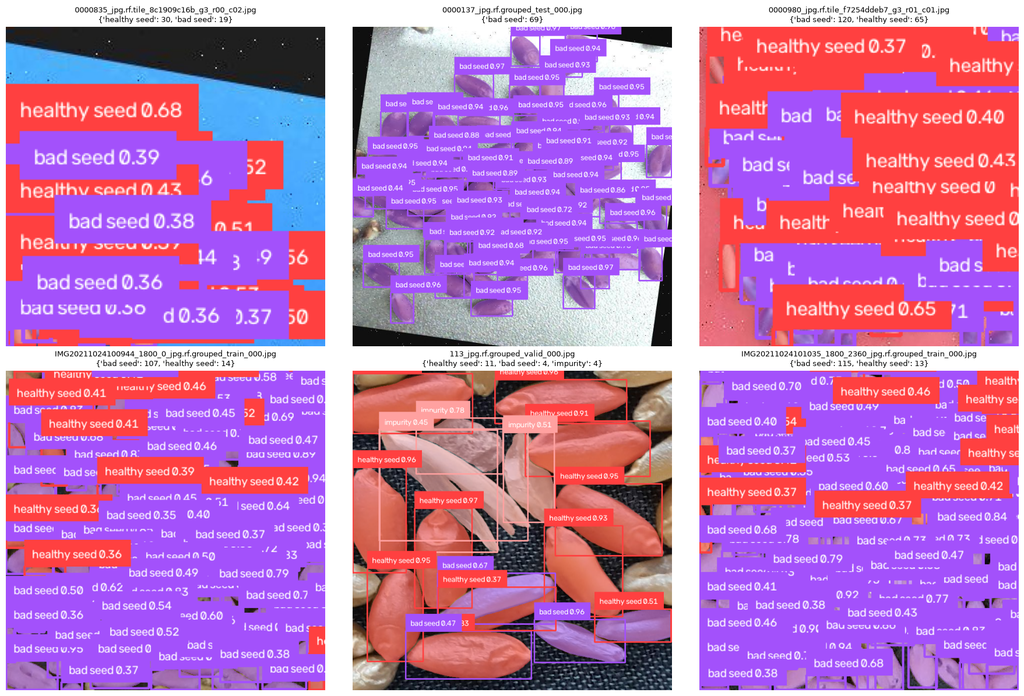

```python
import supervision as sv

selected_test_images = random.Random(47).sample(test_image_paths, min(6, len(test_image_paths)))
figure, axes = plt.subplots(2, 3, figsize=(18, 12), squeeze=False)

for axis, image_path in zip(axes.flat, selected_test_images):
    image_bgr = cv2.imread(str(image_path))
    detections = model.predict(image_bgr, threshold=0.35)
    labels = [
        f"{CLASS_NAMES[int(class_id)]} {confidence:.2f}"
        for class_id, confidence in zip(detections.class_id, detections.confidence)
    ]
    annotated = sv.MaskAnnotator().annotate(image_bgr.copy(), detections)
    annotated = sv.BoxAnnotator().annotate(annotated, detections)
    annotated = sv.LabelAnnotator().annotate(annotated, detections, labels=labels)
    counts = pd.Series([CLASS_NAMES[int(class_id)] for class_id in detections.class_id]).value_counts().to_dict()
    axis.imshow(cv2.cvtColor(annotated, cv2.COLOR_BGR2RGB))
    axis.set_title(f"{image_path.name}\n{counts}", fontsize=9)
    axis.axis("off")

for axis in axes.flat[len(selected_test_images):]:
    axis.axis("off")
plt.tight_layout()
plt.show()
```

## 15. Large V2 inference latency and final artifacts

```python
latency_image = cv2.imread(str(test_image_paths[0]))
for _ in range(3):
    model.predict(latency_image, threshold=0.35)
torch.cuda.synchronize()

timings = []
for _ in range(20):
    started = time.perf_counter()
    model.predict(latency_image, threshold=0.35)
    torch.cuda.synchronize()
    timings.append((time.perf_counter() - started) * 1000)

mean_ms = float(np.mean(timings))
print(f"Mean end-to-end latency: {mean_ms:.1f} ms | Approx. FPS: {1000 / mean_ms:.1f}")
print("\nFinal artifacts")
print(f"Best Large V2 model : {BEST_CHECKPOINT}")
print(f"Test metrics        : {REPORT_DIR / 'test_metrics.csv'}")
print(f"Confusion matrix    : {REPORT_DIR / 'classification_confusion_matrix.csv'}")
print(f"Dataset fingerprint : {REPORT_DIR / 'dataset_fingerprint.txt'}")
```

```
Mean end-to-end latency: 46.0 ms | Approx. FPS: 21.8

Final artifacts
Best Large V2 model : /home/multispector2/testdino/outputRFDetrV2/training/checkpoint_best_regular.pth
Test metrics        : /home/multispector2/testdino/outputRFDetrV2/reports/test_metrics.csv
Confusion matrix    : /home/multispector2/testdino/outputRFDetrV2/reports/classification_confusion_matrix.csv
Dataset fingerprint : /home/multispector2/testdino/outputRFDetrV2/reports/dataset_fingerprint.txt
```

## 16. Export this executed notebook to HTML

After saving the notebook outputs, run this command from `/home/multispector2/testdino` without `--execute`:

```
jupyter nbconvert --to html notebooks/01_rfdetr_segmentation_large_poc_data_v2.ipynb \
  --output-dir /home/multispector2/testdino/outputRFDetrV2/reports \
  --output rfdetr_segmentation_large_v2_results
```